# Regression Analysis on Car Seat Data

After exploring the data and already finding some apparent relationships, we are going to build some regression models to predict the sale prices.

Author: Julia Hammerer, Vanessa Mai  
Last Changes: 10.12.2018

# Table of Contents

```python
import sys
sys.path.insert(0, '../helper/')
```

```python
# load packages
%matplotlib inline
import numpy as np
import pandas as pd
import seaborn as sns
import pandas_profiling
import missingno as msno
import matplotlib.pyplot as plt
import plotly.graph_objs as go
import warnings
import math
import statsmodels.formula.api as smf
import statsmodels.api as sm

from statsmodels.compat import lzip
from slugify import slugify
from pandas.tools.plotting import table
from plotly.offline import init_notebook_mode
from plotly.offline import iplot
from plotly.offline import plot
from scipy.stats import mannwhitneyu
from statsmodels.distributions.empirical_distribution import ECDF
from scipy import stats
from scipy.stats import pearsonr
from scipy.stats import norm
from sklearn.metrics import mean_squared_error, r2_score
from sklearn.dummy import DummyClassifier, DummyRegressor
from sklearn.model_selection import StratifiedKFold, cross_val_score, train_test_split, KFold, cross_val_predict
from sklearn.preprocessing import StandardScaler
from sklearn.linear_model import Lasso, LassoCV, ElasticNetCV, ElasticNet
from sklearn.neighbors import KNeighborsRegressor
from sklearn.cross_decomposition import PLSRegression, PLSSVD
from math import sqrt
from sklearn.decomposition.pca import PCA
from sklearn.linear_model import LinearRegression


from helper import na_ratio_table
from helper import rmsle
from helper import reg_line
from helper import reg_model_results_plots
from helper import regression_model_metrics
from helper import results_summary_to_dataframe
from helper import lin_model
from helper import get_model_results
from helper import reg_model_results_plots
from helper import resid_plot
from helper import cross_fold
from helper import get_baseline_for_regression
from helper import outliers_idx
```

```python
warnings.filterwarnings('ignore')
```

## Function Definitions

Functions that have been created have been moved to the helper file, as they can be reused for different notebooks and in order to keep this notebook lean.

```python
# all_models = pd.DataFrame(columns=['Model','train_res_df','test_res_df',
#                                    'mse_train','mse_test','rmsle_train',
#                                    'rmsle_test', 'r2_train', 'r2_test',
#                                    'se_train', 'se_test', 'train_obs',
#                                    'test_obs', 'outliers_obs'])

# def add_model_to_overview(model_summaries, modelname):
#     model_dic={}
# #     model_df=pd.DataFrame(columns=['Model','train_res_df','test_res_df',
# #                                    'mse_train','mse_test','rmsle_train',
# #                                    'rmsle_test', 'r2_train', 'r2_test',
# #                                    'se_train', 'se_test', 'train_obs',
# #                                    'test_obs', 'outliers_obs'])
#     model_dic.update({"Model":modelname})
#     model_dic.update({"train_res_df": model_summaries['train_res_df']})
#     model_dic.update({"test_res_df":model_summaries['test_res_df']})
#     model_dic.update({"mse_train":model_summaries['mse_train']})
#     model_dic.update({"mse_test":model_summaries['mse_test']})
#     model_dic.update({"r2_train":model_summaries['r2_train']})
#     model_dic.update({"r2_test":model_summaries['rmsle_train']})
#     model_dic.update({"rmsle_train":model_summaries['rmsle_test']})
#     model_dic.update({"rmsle_test":model_summaries['r2_test']})
#     model_dic.update({"se_train":model_summaries['se_train']})
#     model_dic.update({"se_test":model_summaries['se_test']})
#     model_dic.update({"train_obs":model_summaries['train_obs']})
#     model_dic.update({"test_obs":model_summaries['test_obs']})
#     model_dic.update({"outliers_obs":model_summaries['outliers_obs']})
#     model_df=pd.DataFrame(model_dic,index=[0])
```

## Data Preparation

In the EDA we saw that the data was quite clean, we only need to remove the ID "Unnamed: 0". There is no need for further data cleaning or specific preparation. We only need to prepare the training and testing set.

```python
# load data
df = pd.read_csv("../data/Carseats.csv")
```

```python
df.head()
```

|  | Unnamed: 0 | Sales | CompPrice | Income | Advertising | Population | Price | ShelveLoc | Age | Education | Urban | US |
| --- | --- | --- | --- | --- | --- | --- | --- | --- | --- | --- | --- | --- |
| 0 | 1 | 9.50 | 138 | 73 | 11 | 276 | 120 | Bad | 42 | 17 | Yes | Yes |
| 1 | 2 | 11.22 | 111 | 48 | 16 | 260 | 83 | Good | 65 | 10 | Yes | Yes |
| 2 | 3 | 10.06 | 113 | 35 | 10 | 269 | 80 | Medium | 59 | 12 | Yes | Yes |
| 3 | 4 | 7.40 | 117 | 100 | 4 | 466 | 97 | Medium | 55 | 14 | Yes | Yes |
| 4 | 5 | 4.15 | 141 | 64 | 3 | 340 | 128 | Bad | 38 | 13 | Yes | No |

```python
df.drop(columns="Unnamed: 0", inplace=True)
```

```python
CAT_FEATURES =df.select_dtypes(include="object").columns.tolist()
```

```python
CAT_FEATURES
```

```
['ShelveLoc', 'Urban', 'US']
```

```python
df_hot1encoded= pd.get_dummies(df, columns=CAT_FEATURES, prefix=CAT_FEATURES, drop_first=True)
```

```python
df_hot1encoded.head()
```

|  | Sales | CompPrice | Income | Advertising | Population | Price | Age | Education | ShelveLoc_Good | ShelveLoc_Medium | Urban_Yes | US_Yes |
| --- | --- | --- | --- | --- | --- | --- | --- | --- | --- | --- | --- | --- |
| 0 | 9.50 | 138 | 73 | 11 | 276 | 120 | 42 | 17 | 0 | 0 | 1 | 1 |
| 1 | 11.22 | 111 | 48 | 16 | 260 | 83 | 65 | 10 | 1 | 0 | 1 | 1 |
| 2 | 10.06 | 113 | 35 | 10 | 269 | 80 | 59 | 12 | 0 | 1 | 1 | 1 |
| 3 | 7.40 | 117 | 100 | 4 | 466 | 97 | 55 | 14 | 0 | 1 | 1 | 1 |
| 4 | 4.15 | 141 | 64 | 3 | 340 | 128 | 38 | 13 | 0 | 0 | 1 | 0 |

### Create Training and Testingset

```python
FEATURE_COLS=df_hot1encoded.drop(columns="Sales").columns
```

```python
X= df_hot1encoded[FEATURE_COLS]
y= df_hot1encoded["Sales"]
```

```python
# 70% Training, 30% Testing
X_train, X_test, y_train, y_test = train_test_split(X, y, test_size=0.3, random_state=0)
```

```python
print(X_train.shape)
print(X_test.shape)
```

```
(280, 11)
(120, 11)
```

### Normalize Data with Standardscaler

```python
# we also will use a StandardScaler in a second set

standardizer = StandardScaler().fit(X_train)

# FEATURE_COLS=df_hot1encoded.drop(columns="saleprice").columns

scaled_features=standardizer.transform(df_hot1encoded[FEATURE_COLS].values)
```

```python
feature_df=feature_df=pd.DataFrame(scaled_features, index=df_hot1encoded[FEATURE_COLS].index, columns= df_hot1encoded[FEATURE_COLS].columns)
```

```python
X_train_scaled, X_test_scaled, y_train_scaled, y_test_scaled = train_test_split(feature_df.copy(), y.copy(), test_size=0.3, random_state=0)
```

### Handle outliers

```python
df_all=X.copy()
df_all["Sales"]=y.copy()
outliers = outliers_idx(df_all, "Sales")
outliers_df = X.loc[X.index.isin(outliers)]
```

```python
outliers_df
```

|  | CompPrice | Income | Advertising | Population | Price | Age | Education | ShelveLoc_Good | ShelveLoc_Medium | Urban_Yes | US_Yes |
| --- | --- | --- | --- | --- | --- | --- | --- | --- | --- | --- | --- |
| 376 | 141 | 60 | 19 | 319 | 92 | 44 | 11 | 1 | 0 | 1 | 1 |

1 outlier will be removed.

```python
# #filter outliers
X= X.loc[~X.index.isin(outliers)]
y= y.loc[~y.index.isin(outliers)]
```

```python
X.shape
```

```
(399, 11)
```

```python
df=X_train.copy()
df["Sales"]=y_train.copy()
outliers = outliers_idx(df, "Sales")
outliers_df = X_train.loc[X_train.index.isin(outliers)]
```

```python
X_train.shape
```

```
(280, 11)
```

```python
# #filter outliers for training
X_train= X_train.loc[~X_train.index.isin(outliers)]
y_train= y_train.loc[~y_train.index.isin(outliers)]
```

```python
X_train.shape
```

```
(279, 11)
```

```python
df_scaled=X_train_scaled.copy()
df_scaled["Sales"]=y_train_scaled.copy()
outliers_scaled = outliers_idx(df_scaled, "Sales")
outliers_df_scaled = X_train_scaled.loc[X_train_scaled.index.isin(outliers)]
```

```python
# #filter outliers for training
X_train_scaled= X_train_scaled.loc[~X_train.index.isin(outliers)]
y_train_scaled= y_train_scaled.loc[~y_train.index.isin(outliers)]
```

## Baseline Model

Let's start with building a baseline model, which is simply the means of all Sales.

```python
# create Dummyregressor
Baseline = DummyRegressor(strategy='mean')

Baseline.fit(X_train, y_train)
Baseline.predict(X_test)
# Mean Accuracy ausgeben
print('Baseline MSE: %.2f' % mean_squared_error(Baseline.predict(X_test), y_test))
baseline_mse=mean_squared_error(Baseline.predict(X_test), y_test)
```

```
Baseline MSE: 6.90
```

Our baseline model, which uses the mean of all Sales of the Training set gives us a MSE of 6.90. Using different statistcal and machine learning methods we want to improve this score now.

## Ordinary Least Square Regression Model (Iteration 1)

- all variables

```python
# let's start with a simple model and no further adjustments, we just put in all variables we have
ols_model = sm.OLS(y_train, X_train).fit()
```

```python
y_pred=ols_model.predict(X_train)
mean_squared_error(y_pred, y_train)
```

```
1.2104441727185185
```

We can already see, that the MSE is much lower than our Baseline.

```python
y_pred = ols_model.get_prediction(X_test)
```

```python
y_pred=ols_model.predict(X_test)
mean_squared_error(y_pred, y_test)
```

```
1.394199557620503
```

Also, for the testing set, the results seem to be quite good in comparison with the Baseline.

```python
ols_model.summary()
```

OLS Regression Results

| Dep. Variable: | Sales | R-squared: | 0.981 |
| --- | --- | --- | --- |
| Model: | OLS | Adj. R-squared: | 0.980 |
| Method: | Least Squares | F-statistic: | 1227. |
| Date: | Mon, 10 Dec 2018 | Prob (F-statistic): | 4.41e-222 |
| Time: | 18:41:40 | Log-Likelihood: | -422.53 |
| No. Observations: | 279 | AIC: | 867.1 |
| Df Residuals: | 268 | BIC: | 907.0 |
| Df Model: | 11 |  |  |
| Covariance Type: | nonrobust |  |  |

|  | coef | std err | t | P>\|t\| | [0.025 | 0.975] |
| --- | --- | --- | --- | --- | --- | --- |
| CompPrice | 0.1228 | 0.005 | 27.062 | 0.000 | 0.114 | 0.132 |
| Income | 0.0198 | 0.002 | 8.213 | 0.000 | 0.015 | 0.025 |
| Advertising | 0.1311 | 0.015 | 9.027 | 0.000 | 0.103 | 0.160 |
| Population | 0.0009 | 0.000 | 1.941 | 0.053 | -1.31e-05 | 0.002 |
| Price | -0.0994 | 0.004 | -27.811 | 0.000 | -0.106 | -0.092 |
| Age | -0.0321 | 0.004 | -8.165 | 0.000 | -0.040 | -0.024 |
| Education | 0.0409 | 0.023 | 1.765 | 0.079 | -0.005 | 0.086 |
| ShelveLoc_Good | 5.0567 | 0.204 | 24.740 | 0.000 | 4.654 | 5.459 |
| ShelveLoc_Medium | 2.1990 | 0.161 | 13.697 | 0.000 | 1.883 | 2.515 |
| Urban_Yes | 0.1101 | 0.150 | 0.733 | 0.464 | -0.186 | 0.406 |
| US_Yes | -0.1056 | 0.198 | -0.534 | 0.594 | -0.495 | 0.283 |

| Omnibus: | 1.009 | Durbin-Watson: | 1.897 |
| --- | --- | --- | --- |
| Prob(Omnibus): | 0.604 | Jarque-Bera (JB): | 0.809 |
| Skew: | 0.124 | Prob(JB): | 0.667 |
| Kurtosis: | 3.090 | Cond. No. | 1.21e+03 |

Warnings:  
[1] Standard Errors assume that the covariance matrix of the errors is correctly specified.  
[2] The condition number is large, 1.21e+03. This might indicate that there are  
strong multicollinearity or other numerical problems.

MSE for both training AND testing set are much lower than the Baseline. The model performs quite well, with high R2, adj. R2 and F-Score

First, we check the coefficents and p-values for each attributes. Let's have a look at those with p-values lower than the thumbrule 0.05.

```python
ols_attr= results_summary_to_dataframe(ols_model)
```

```python
ols_attr= ols_attr[ols_attr.pvals<=0.05]#.reset_index()
```

```python
len(ols_attr)
```

```
7
```

We would have 7 attributes for which we could reject the 0-Hypothesis, based on the OLS. Let's try building a model using these attributes.

## Ordinary Least Square Regression Model (Iteration 2)

- remove iteratively non-significant variables based on p-values of variables

```python
ols_model_summaries={}
y_pred_name = "sales_predicted"
```

```python
ols_model_2 = sm.OLS(y_train, X_train).fit()

while results_summary_to_dataframe(ols_model_2)["pvals"].apply(lambda x: x >= 0.05).any():
    ols_model_sign_attr=[]
    for i, e in enumerate(results_summary_to_dataframe(ols_model_2)["pvals"]):
        if e <=0.05:
            ols_model_sign_attr.append(results_summary_to_dataframe(ols_model_2).iloc[i]["attributes"])
    ols_model_2 = sm.OLS(y_train, X_train[ols_model_sign_attr]).fit()
```

```python
# Test results
reg_test = ols_model_2.predict(X_test[ols_model_sign_attr])

# get results
reg_train_results_df = pd.DataFrame({"Sales": y_train.copy()})
reg_train_results_df[y_pred_name] = ols_model_2.fittedvalues
reg_train_results_df['set'] = 'TRAIN'

reg_test_results_df = pd.DataFrame({"Sales": y_test.copy()})
reg_test_results_df[y_pred_name] = reg_test
reg_test_results_df['set'] = 'TEST'

# metrics
baseline_val, baseline_mse, baseline_rmsle = get_baseline_for_regression(
    X_train=X_train,
    y_train=reg_train_results_df["Sales"],
    X_test=X_test,
    y_test=reg_test_results_df["Sales"])

mse_train, r2_train, adj_r2_train, st_error_train = regression_model_metrics(
    y=reg_train_results_df["Sales"],
    y_predicted=reg_train_results_df[y_pred_name],
    X=X_train)

mse_test, r2_test,adj_r2_test, st_error_test = regression_model_metrics(
    y=reg_test_results_df["Sales"],
    y_predicted=reg_test_results_df[y_pred_name],
    X=X_test)

rmsle_train=rmsle(ytest=reg_train_results_df["Sales"],
                    ypred=reg_train_results_df[y_pred_name])
rmsle_test=rmsle(ytest=reg_test_results_df["Sales"],
                     ypred=reg_test_results_df[y_pred_name])

ols_model_summaries = {'y_pred_name': y_pred_name,
                       'train_res_df': reg_train_results_df,
                       'test_res_df': reg_test_results_df,
                       'baseline_mse': baseline_mse,
                       'baseline_val': baseline_val,
                       'baseline_rmsle':baseline_rmsle,
                       'mse_train': mse_train,
                       'mse_test': mse_test,
                       'rmsle_train': rmsle_train,
                       'rmsle_test':rmsle_test,
                       'r2_train': r2_train,
                       'adj_r2_train': adj_r2_train,
                       'r2_test': r2_test,
                       'adj_r2_test': adj_r2_test,
                       'se_train': st_error_train,
                       'se_test': st_error_test,
                       'model_report': ols_model_2.summary(),
                       'train_obs': reg_train_results_df.shape[0],
                       'test_obs': reg_test_results_df.shape[0]}
# put all this in a function in case, i want to repeat this analysis
```

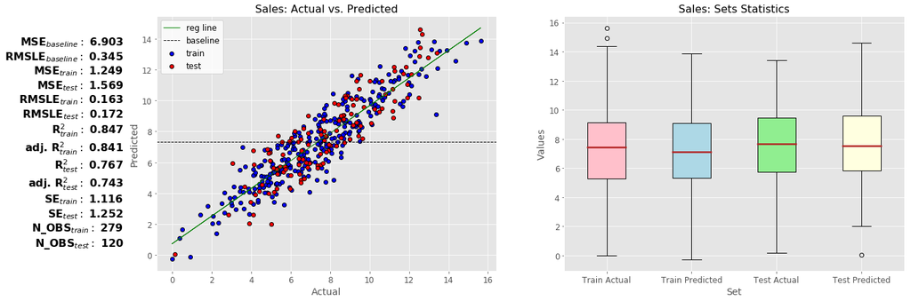

```python
reg_model_results_plots(model_summaries=ols_model_summaries, y_pred_name="Sales_pred", y_name="Sales")
```

Results are surprisingly good, given that we barely optimize the model, the MSE is definitely smaller than are benchmark/baseline. if we look at the plot that compares Actual vs. Predicted, the data points are quite close to our regression line, which indicates a good prediction. If the data points were exactly on the regression line, we would have a perfect regression.

### Residuals vs. Fitted

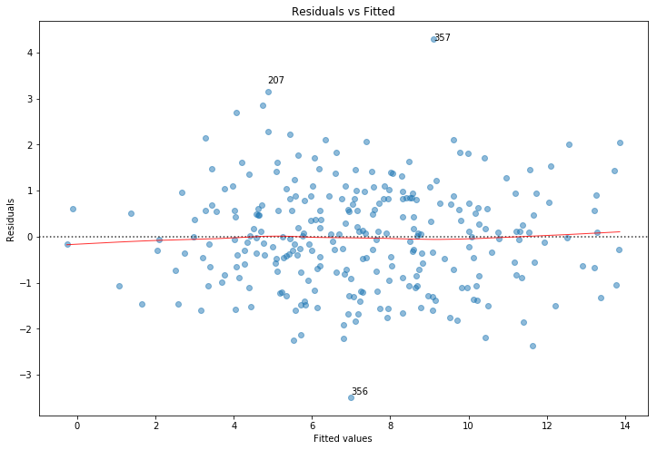

```python
resid_plot(ols_model_2, y_train)
```

The residuals are close to but not exactly spread around a horizontal line.

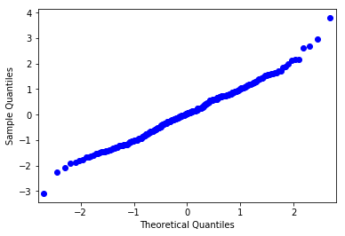

```python
sm.qqplot(ols_model_2.get_influence().resid_studentized_internal);
```

## Ordinary Least Square Regression Model (Iteration 3)

- use scaled data

```python
ols_model_3 = sm.OLS(y_train_scaled, X_train_scaled).fit()
```

```python
ols_model_3, ols_model_3_summary, sign_attr_3=lin_model(y_train_scaled, X_train_scaled, y_test_scaled, X_test_scaled,
                                                        reg_model="OLS",
                                                        y_pred_name="Sales_pred",
                                                        y_name="Sales")
```

```python
ols_model_3_summary
```

[output not shown]

[output cut: 140 more lines]

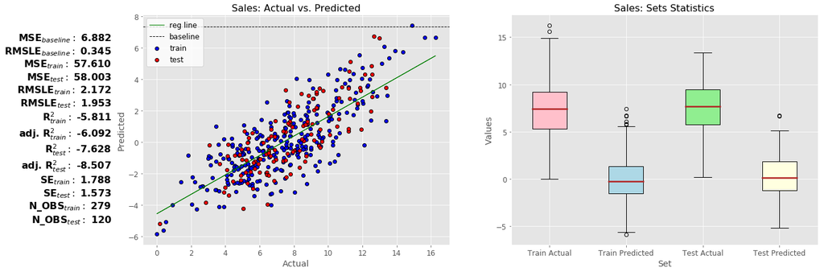

```python
reg_model_results_plots(model_summaries=ols_model_3_summary, y_pred_name="Sales_pred", y_name="Sales")
```

Using the standardized data results in a much worse result. We also have negative values, which should not be possible.

### Residuals vs. Fitted

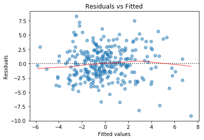

```python
# fitted values
model_fitted_y_2 = ols_model_3.fittedvalues;
# Basic plot
plot = sns.residplot(model_fitted_y_2, y_train, lowess=True,
                     scatter_kws={'alpha': 0.5},
                     line_kws={'color': 'red',
                               'lw': 1, 'alpha': 0.8});

plot.set_title('Residuals vs Fitted');
plot.set_xlabel('Fitted values');
plot.set_ylabel('Residuals');
```

## Ordinary Least Square - Cross Validation

- using the model from second iteration

```python
predictors=" + ".join(ols_model_sign_attr)
```

```python
predictors
```

```
'CompPrice + Income + Advertising + Price + Age + ShelveLoc_Good + ShelveLoc_Medium'
```

```python
# Model 1
results = cross_fold(df_hot1encoded, response='Sales', predictors=predictors)
display(results)
print(f'MSE Mean: {results["MSE"].mean():.2f}')
print(f'RMSLE Mean: {results["RMSLE"].mean():.2f}')
```

|  | Fold | MSE | RMSLE |
| --- | --- | --- | --- |
| 0 | 0 | 1.077446 | 0.148517 |
| 1 | 1 | 0.923261 | 0.136391 |
| 2 | 2 | 0.921108 | 0.135056 |
| 3 | 3 | 1.572794 | 0.189884 |
| 4 | 4 | 0.975144 | 0.163242 |
| 5 | 5 | 1.161837 | 0.141603 |
| 6 | 6 | 0.725527 | 0.106824 |
| 7 | 7 | 1.003607 | 0.143822 |
| 8 | 8 | 1.084997 | 0.231788 |
| 9 | 9 | 1.119861 | 0.140617 |

```
MSE Mean: 1.06
RMSLE Mean: 0.15
```

## General Least Square Regression

```python
gls_model, gls_model_summary, gls_sign_attr=lin_model(y_train, X_train, y_test, X_test,
                                                      reg_model="GLS",
                                                      y_pred_name="Sales_pred",
                                                      y_name="Sales")
```

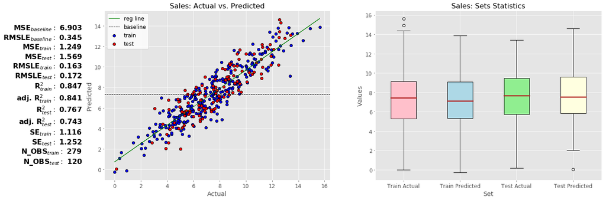

```python
reg_model_results_plots(model_summaries=gls_model_summary,
                        y_pred_name="Sales_pred",
                        y_name="Sales")
```

### Residuals vs. Fitted

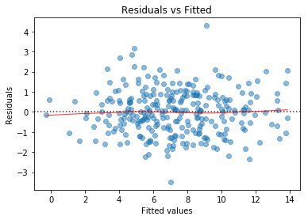

```python
# Basic plot
plot = sns.residplot(gls_model.fittedvalues, y_train, lowess=True,
                     scatter_kws={'alpha': 0.5},
                     line_kws={'color': 'red',
                               'lw': 1, 'alpha': 0.8});

plot.set_title('Residuals vs Fitted');
plot.set_xlabel('Fitted values');
plot.set_ylabel('Residuals');
```

## Lasso Regression Iteration 1

Lasso helps us to reduce dimensions and drop unimportant attributes.

```python
lasso1 = Lasso()
lasso1.set_params(alpha=0.5)
lasso1.fit(X_train, y_train)
print(lasso1.score(X_train, y_train))
print(lasso1.score(X_test, y_test))
```

```
0.5962156728254253
0.42438017644213905
```

The R2 Scores are not very high. Let's have a further look

```python
y_pred=lasso1.predict(X_test)
```

```python
lasso_coef1=pd.Series(lasso1.coef_, index=X_train.columns)
```

```python
(lasso_coef1[(lasso_coef1==0)].index.tolist())
```

```
['Education', 'ShelveLoc_Medium', 'Urban_Yes', 'US_Yes']
```

We can see plenty 4 attributes which have coefficents of zero. Those are identified as irrelevant by the lasso regression and we are going to remove those from the analysis.

```python
# make function to get number of irrelevant attributes
def get_irr_attr_lasso(lasso_model, X_train):
    lasso_coef=pd.Series(lasso_model.coef_, index=X_train.columns)
    irr_attr_lasso=lasso_coef[(lasso_coef==0)].index.tolist()
    return irr_attr_lasso
```

```python
# make function to get number of irrelevant attributes
def get_attr_lasso(lasso_model, X_train):
    lasso_coef=pd.Series(lasso_model.coef_, index=X_train.columns)
    attr_lasso=lasso_coef[(lasso_coef!=0)].index.tolist()
    return attr_lasso
```

```python
get_irr_attr_lasso(lasso1, X_train)
```

```
['Education', 'ShelveLoc_Medium', 'Urban_Yes', 'US_Yes']
```

```python
lasso_attr=lasso_coef1[lasso_coef1!=0]
```

```python
lasso_attr.shape
```

```
(7,)
```

```python
lasso_attr=lasso_attr.index.tolist()
```

```python
lasso = Lasso()
lasso.set_params(alpha=0.5)
lasso.fit(X_train[lasso_attr], y_train)
print(lasso.score(X_train[lasso_attr], y_train))
print(lasso.score(X_test[lasso_attr], y_test))
```

```
0.5962156728254253
0.42438017644213905
```

```python
y_pred=lasso.predict(X_test[lasso_attr])
```

```python
mse_test, r2_test, adj_r2_test, st_error_test = regression_model_metrics(y_test, y_pred,
                                                                         X_test)
```

```python
lasso, lasso_summaries =  get_model_results(lasso,y_train, X_train[lasso_attr],
                                            y_test, X_test[lasso_attr],
                                            y_pred_name="Sales_pred",
                                            y_name="Sales")
```

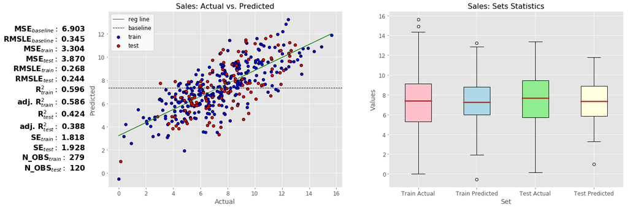

```python
reg_model_results_plots(lasso_summaries,
                        y_pred_name="Sales_pred",
                        y_name="Sales")
```

The lasso regression yields worse results than the simpler OLS and GLS

## Lasso Regression Iteration 2

- Using various alphas and comparing results

```python
def lasso_r2(lambdas, X_train, y_train, X_test, y_test):
    '''
    Takes in a list of lambdas.
    Outputs a dataframe containing the r2 of lasso regressions
    from each lambda for training and testing data set.

    '''
    columns_list=["lambda", "R2_training", "R2_testing"]
    r_scores=pd.DataFrame(columns=columns_list)

    for l in lambdas:
        lasso=Lasso()
        lasso.set_params(alpha=l)
        lasso.fit(X_train, y_train)
        R2_train=lasso.score(X_train, y_train)
        R2_test=lasso.score(X_test, y_test)
        row=pd.DataFrame([[l,R2_train, R2_test]], columns=columns_list)
        r_scores=r_scores.append(row)
    return r_scores

def plot_lasso_lambdas(r_scores):
    plt.figure(figsize=(15,8))
    ax=plt.plot( 'lambda', 'R2_training', data=r_scores, marker='o', markerfacecolor='blue', markersize=12, color='skyblue', linewidth=4)
    ax=plt.plot( 'lambda', 'R2_testing', data=r_scores, marker='o', markerfacecolor='red', markersize=12, color='tomato', linewidth=4)
#     plt.xscale("log")
    plt.legend()
```

```python
l_min = 0.05
l_max = 20
l_num = 20
lambdas = np.linspace(l_min,l_max, l_num)
```

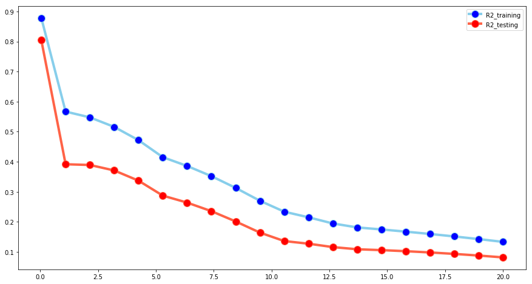

```python
plot_lasso_lambdas(lasso_r2(lambdas, X_train, y_train, X_test, y_test))
```

```python
lasso_r2_results=lasso_r2(lambdas, X_train, y_train, X_test, y_test)
```

```python
lasso_r2_results=lasso_r2_results.reset_index().drop(columns="index")
```

```python
lasso_r2_results["R2_testing"].idxmax()
```

```
0
```

```python
lasso_r2_results.ix[lasso_r2_results["R2_testing"].idxmax()]
```

```
lambda         0.050000
R2_training    0.878218
R2_testing     0.804402
Name: 0, dtype: float64
```

```python
lasso2=Lasso()
lasso2.set_params(alpha=0.05)
lasso2.fit(X_train[lasso_attr], y_train)
```

```
Lasso(alpha=0.05, copy_X=True, fit_intercept=True, max_iter=1000,
   normalize=False, positive=False, precompute=False, random_state=None,
   selection='cyclic', tol=0.0001, warm_start=False)
```

```python
lasso2, lasso_summaries2 =  get_model_results(lasso2,y_train,
                                              X_train[lasso_attr],
                                              y_test,
                                              X_test[lasso_attr],
                                              y_pred_name="Sales_pred",
                                              y_name="Sales")
```

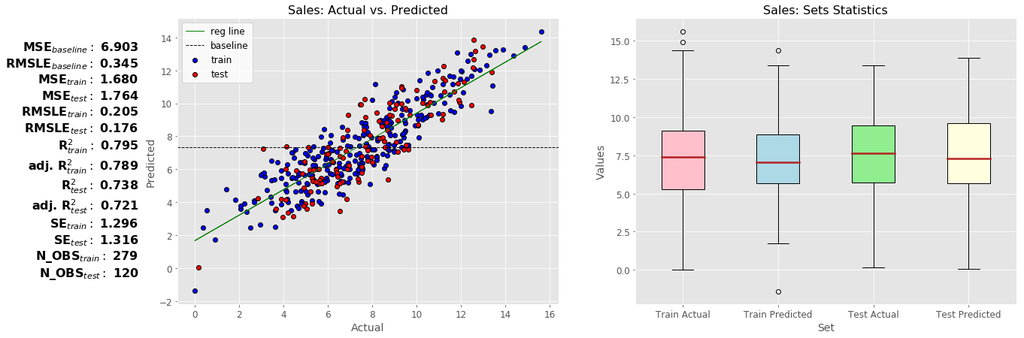

```python
reg_model_results_plots(lasso_summaries2,
                        y_pred_name="Sales_pred",
                        y_name="Sales")
```

Also, a decent mode.

```python
len(get_attr_lasso(lasso2, X_train[lasso_attr]))
```

```
7
```

```python
get_attr_lasso(lasso2, X_train[lasso_attr])
```

```
['CompPrice',
 'Income',
 'Advertising',
 'Population',
 'Price',
 'Age',
 'ShelveLoc_Good']
```

## Lasso Regression iteration 3

Crossvalidation

```python
lasso_3 = LassoCV(cv=10, random_state=0, normalize=True).fit(X, y)
lasso_3.score(X,y)
```

```
0.8703187671290147
```

```python
lasso_3, lasso_summaries_3 =  get_model_results(lasso_3,y, X, y, X,
                                              y_pred_name="Sales_pred",
                                              y_name="Sales")
```

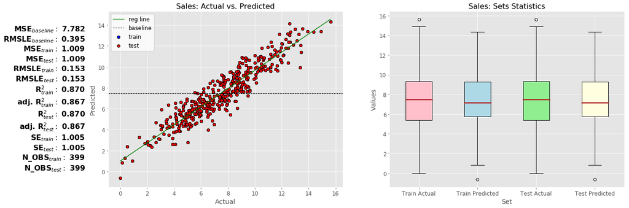

```python
reg_model_results_plots(lasso_summaries_3,
                        y_pred_name="Sales_pred",
                        y_name="Sales")
```

Best Model so far. (based on MSE)

```python
display(get_attr_lasso(lasso_3, X_train))
display(len(get_attr_lasso(lasso_3, X_train)))
```

```
['CompPrice',
 'Income',
 'Advertising',
 'Population',
 'Price',
 'Age',
 'Education',
 'ShelveLoc_Good',
 'ShelveLoc_Medium',
 'Urban_Yes',
 'US_Yes']
```

```
11
```

```python
get_irr_attr_lasso(lasso_3, X_train)
```

```
[]
```

This model uses all attributes.

```python
lasso_3_coef = pd.Series(lasso_3.coef_, index = X_train.columns).sort_values()
lasso_3_coef = lasso_3_coef[lasso_3_coef!=0]
```

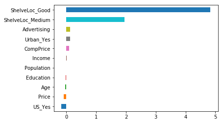

```python
lasso_3_coef.plot(kind="barh")
```

## Lasso Regression Iteration 4

- Cross validation
- optimization of alphas

```python
l_min = 0.05
l_max = 20
l_num = 20
lambdas = np.linspace(l_min,l_max, l_num)
```

```python
lasso4 = LassoCV(cv=10, random_state=0, alphas=lambdas, fit_intercept=True).fit(X, y)
lasso4.score(X,y)
```

```
0.8618816611667021
```

```python
lasso4, lasso_summaries_4 =  get_model_results(lasso4,y, X, y, X,
                                               y_pred_name="Sales_pred",
                                               y_name="Sales")
```

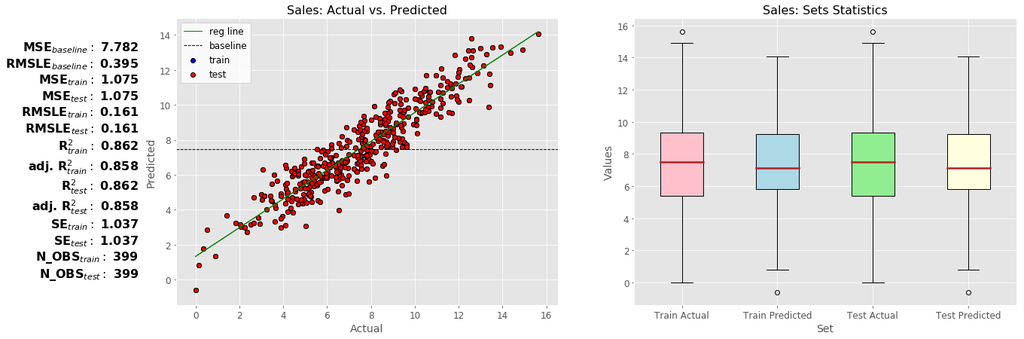

```python
reg_model_results_plots(lasso_summaries_4,
                        y_pred_name="Sales_pred",
                        y_name="Sales")
```

```python
lasso4.alpha_
```

```
0.05
```

Best alpha: `0.05`

Using an intercept and an optimization of the alphas results in quite a good result. The MSE is very low in comparison and also the R2 is good.

## Elastic Nets Iteration 1

Elastic Nets is a combination of Lasso and Ridge Regression.

We will use CV for this only.

```python
alphas = [0.0005, 0.001, 0.01, 0.03, 0.05, 0.1]
l1_ratios = [ .1, .5, .7, .8, .9, .95, .99, 1]
```

```python
ElasticNet1 = ElasticNetCV(cv=5, random_state=0, l1_ratio =l1_ratios, alphas=lambdas, fit_intercept=True )
```

```python
ElasticNet1.fit(X, y)
```

```
ElasticNetCV(alphas=array([ 0.05,  1.1 ,  2.15,  3.2 ,  4.25,  5.3 ,  6.35,  7.4 ,  8.45,
        9.5 , 10.55, 11.6 , 12.65, 13.7 , 14.75, 15.8 , 16.85, 17.9 ,
       18.95, 20.  ]),
       copy_X=True, cv=5, eps=0.001, fit_intercept=True,
       l1_ratio=[0.1, 0.5, 0.7, 0.8, 0.9, 0.95, 0.99, 1], max_iter=1000,
       n_alphas=100, n_jobs=None, normalize=False, positive=False,
       precompute='auto', random_state=0, selection='cyclic', tol=0.0001,
       verbose=0)
```

```python
ElasticNet1, ElasticNet1_summaries =  get_model_results(ElasticNet1,y, X, y, X,
                                                        y_pred_name="Sales_pred",
                                                        y_name="Sales")
```

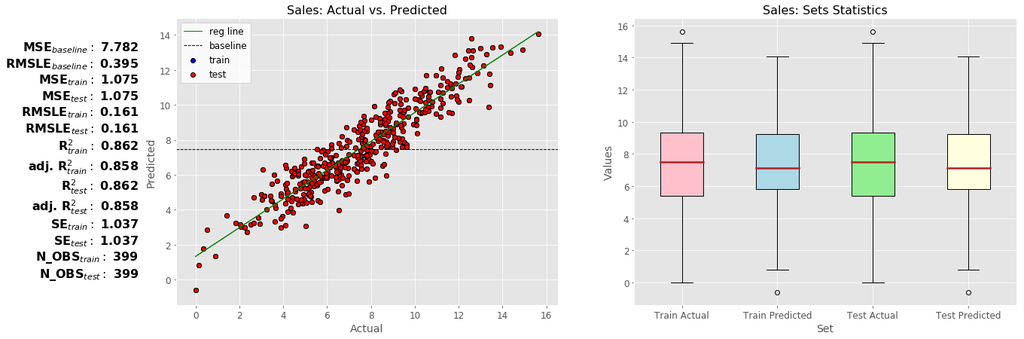

```python
reg_model_results_plots(ElasticNet1_summaries,
                        y_pred_name="Sales_pred",
                        y_name="Sales")
```

```python
print("L1 ratio: ", ElasticNet1.l1_ratio_)
print("Alpha: ", ElasticNet1.alpha_)
```

```
L1 ratio:  1.0
Alpha:  0.05
```

The L1 ration is one, which means that this is basically the Lasso regression, if we look closely we can see, that the results are the same as the last lasso Regression

```python
el_net_coef = pd.Series(ElasticNet1.coef_, index = X_train.columns)
```

```python
el_net_coef=el_net_coef.sort_values()
```

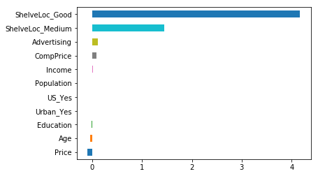

```python
el_net_coef.plot(kind="barh")
```

```python
print("Elastic Net picked " + str(sum(el_net_coef != 0)) + " variables and eliminated the other " +  str(sum(el_net_coef == 0)) + " variables")
```

```
Elastic Net picked 9 variables and eliminated the other 2 variables
```

## Some other methods: KNN-Regression

```python
n_neighbors = 10
```

```python
knn = KNeighborsRegressor(n_neighbors=n_neighbors)
knn.fit(X_train, y_train)
```

```
KNeighborsRegressor(algorithm='auto', leaf_size=30, metric='minkowski',
          metric_params=None, n_jobs=None, n_neighbors=10, p=2,
          weights='uniform')
```

```python
knn, knn_summaries =  get_model_results(knn,y_train, X_train, y_test, X_test, y_pred_name="Sales_pred",
                        y_name="Sales")
```

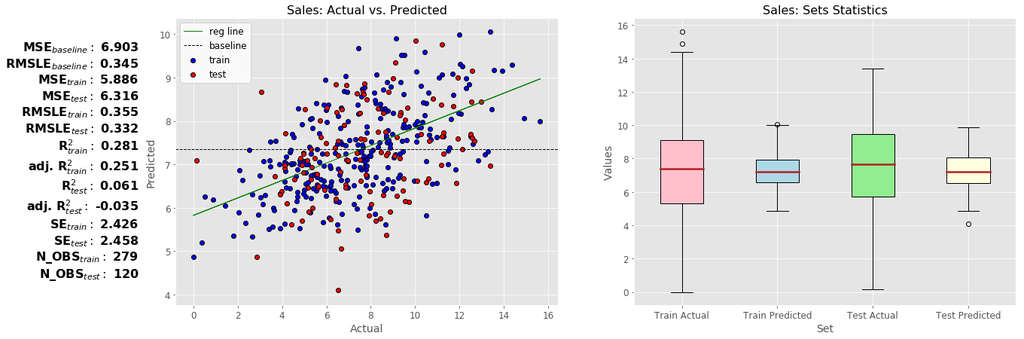

```python
reg_model_results_plots(knn_summaries,y_pred_name="Sales_pred",
                        y_name="Sales")
```

As expected, the results are not very good. The model particularly does not handle values in the upper end very well. It is only a bit smaller than the Baseline Model.

## PCA Analysis

```python
X_values=X.values
y_values=y.values
```

```python
# As we do not know how many components to choose, we select "None"
# as number of components to get an overview over the variance in the dataset
pca= PCA(n_components=None)
X_values_scaled= StandardScaler().fit_transform(X_values)
X_values_scaled= pca.fit_transform(X_values_scaled)
```

```python
# We check our explained variance ratio in the dataset by adding each
# consecutive principal component
np.cumsum(np.round(pca.explained_variance_ratio_,decimals=4)*100)
```

```
array([ 16.73,  31.82,  45.66,  55.66,  65.2 ,  74.08,  82.37,  90.02,
        93.85,  97.5 , 100.01])
```

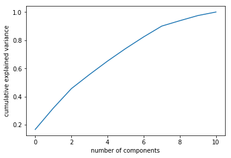

```python
# For better understanding we plot the variance curve.
plt.plot(np.cumsum(pca.explained_variance_ratio_))
plt.xlabel('number of components')
plt.ylabel('cumulative explained variance');
```

### PCR Analysis

```python
def pcr(X,y,pc):
    pca3 = PCA()

    X_r= StandardScaler().fit_transform(X)
    X_r= pca.fit_transform(X)

    # Run PCA producing the reduced variable Xreg and select the first pc components
    Xreg = pca.fit_transform(X_r)[:,:pc]

    ''' Step 2: regression on selected principal components'''

    # Create linear regression object
    regr = LinearRegression()

    # Fit
    regr.fit(Xreg, y)

    # prediction of calibration
    y_c = regr.predict(Xreg)

    # Cross-validation
    y_cv = cross_val_predict(regr, Xreg, y, cv=10)

    # Calculate scores for calibration and cross-validation
    score_c = r2_score(y, y_c)
    score_cv = r2_score(y, y_cv)

    # Calculate mean square error for calibration and cross validation
    mse_c = mean_squared_error(y, y_c)
    mse_cv = mean_squared_error(y, y_cv)

    return(regr, y_cv, score_c, score_cv, mse_c, mse_cv, Xreg)
```

```python
pcr, predicted, r2r, r2cv, mser, mscv, x_pcr=pcr(X_values,y_values, pc=7)
```

```python
r2r
```

```
0.5333562916027668
```

```python
pcr, pcr_summaries = get_model_results(pcr,y,x_pcr, y, x_pcr,
                                       y_pred_name="Sales_pred",
                                       y_name="Sales")
```

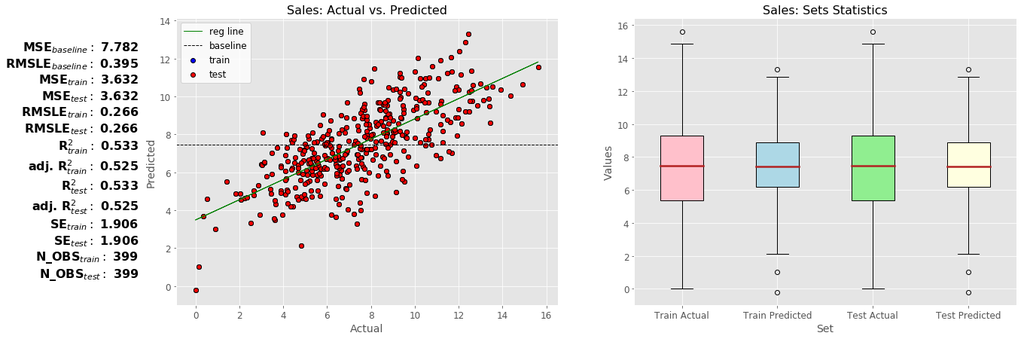

```python
reg_model_results_plots(pcr_summaries, y_pred_name="Sales_pred",
                        y_name="Sales")
```

The model performs very bad compared to other models.

### PLS

Partial Least Squares:

- Technique similar to Principal Component Analysis (PCA).
- Decomposes both the design matrix X and response vector/matrix Y (can have multiple responses at once) like in PCA and then performs regression between the obtained scores matrix and the eigenvectors.
- The idea is to obtain decomposition of X and Y to be done by taking information from each other into account.
- The most important variables can be selected by the VIP score, which measures explicative power of predictor variables with respect to the response variable in all selected components. Normally, the average of the squared values of the VIPs is equal to 1. The criterion of VIP value with greater than 1 is then typically used as a cutoff point for variable selection.

```python
X_train_values=X_train.values
y_train_values=y_train.values
X_test_values=X_test.values
y_test_values=y_test.values
```

```python
mse=[]
component = np.arange(1,11)
```

```python
for i in component:
    pls1= PLSRegression(n_components=i)
    pls1.fit(X_train,y_train)
    y_pred = pls1.predict(X_test)

    mse_p = mean_squared_error(y_test,y_pred)
    mse.append(mse_p)
```

```python
np.argmin(mse)
```

```
3
```

```python
msemin = np.argmin(mse)
print("Suggested number of components: ", msemin+1)
```

```
Suggested number of components:  4
```

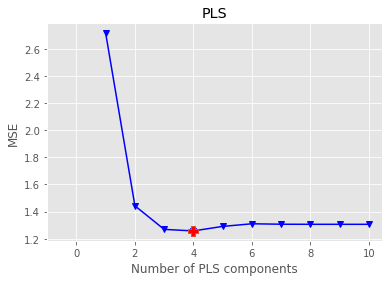

```python
with plt.style.context(('ggplot')):
     plt.plot(component, np.array(mse), '-v', color = 'blue', mfc='blue')
     plt.plot(component[msemin], np.array(mse)[msemin], 'P', ms=10, mfc='red')
     plt.xlabel('Number of PLS components')
     plt.ylabel('MSE')
     plt.title('PLS')
     plt.xlim(xmin=-1)

     plt.show()
```

```python
pls = PLSRegression(n_components=msemin+1)
pls.fit(X_train, y_train)
Y_pred = pls.predict(X_test)
```

```python
pls, pls_summaries = get_model_results(pls,y_train,X_train, y_test, X_test, y_pred_name="Sales_pred",
                        y_name="Sales")
```

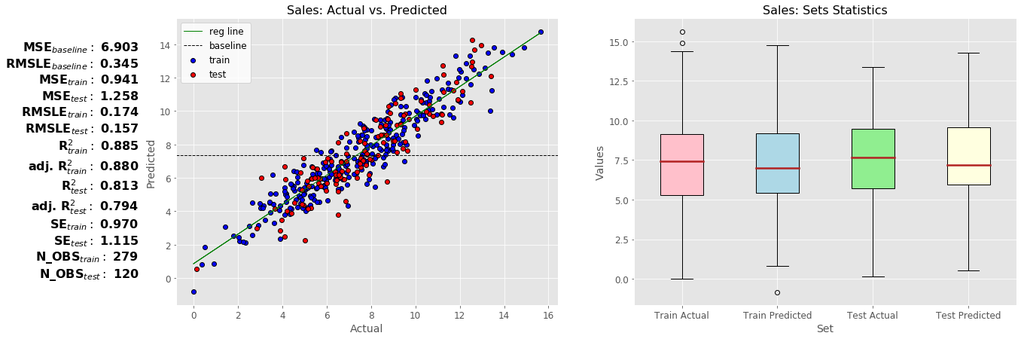

```python
reg_model_results_plots(pls_summaries, y_pred_name="Sales_pred",
                        y_name="Sales")
```

## Summary

The results overall were quite well. The models built using CV were the best (but they also had more samples.) Lasso and ElasticNets help us figuring out the important features